# Data-cleaning and analysis

Federica Mazzucco

2022-09-09

## Understanding the nature of the stimuli

- How many Conditions are there?

```r
unique(select(stimuli, Condition))
```

```
## # A tibble: 5 x 1
##   Condition
##       <dbl>
## 1         1
## 2         2
## 3         3
## 4         4
## 5       100
```

5 Conditions: 1, 2, 3, 4 and 100.

- How many sentences per Condition?

```r
stimuli %>%
  group_by(Condition)%>%
  summarise(Count = n())
```

```
## # A tibble: 5 x 2
##   Condition Count
##       <dbl> <int>
## 1         1    30
## 2         2    30
## 3         3    30
## 4         4    30
## 5       100   100
```

Conditions 1 to 4: 30 sentences.  
Condition 100: 100 sentences.

```r
stimuli %>%
  group_by(AdjectiveUsed)%>%
  summarise(Count = n())
```

```
## # A tibble: 61 x 2
##    AdjectiveUsed Count
##    <chr>         <int>
##  1 �berfordert       2
##  2 �berm�det         2
##  3 atemlos           2
##  4 aufgekratzt       2
##  5 aufgeregt         2
##  6 ausgehungert      2
##  7 autistisch        2
##  8 behindert         2
##  9 besorgt           2
## 10 bet�ubt           2
## # ... with 51 more rows
```

The stimuli contain 60 adjectives in total, each of them paired with the verb “sein” or with the verb “sich verhalten”.

- How are stage-level and individual-level adjectives distributed?

```r
stimuli %>%
  filter(Adjective == "stage-level")%>%
  group_by(Condition)%>%
  summarise(Count = n())
```

```
## # A tibble: 2 x 2
##   Condition Count
##       <dbl> <int>
## 1         1    30
## 2         3    30
```

```r
stimuli %>%
  filter(Adjective == "Individual-level")%>%
  group_by(Condition)%>%
  summarise(Count = n())
```

```
## # A tibble: 2 x 2
##   Condition Count
##       <dbl> <int>
## 1         2    30
## 2         4    30
```

Stage-level adjectives are 60 in total, split equally between Condition 1 and 3.  
Individual-level adjectives are 60, again split equally between condition 2 and 4.

- How many lists? How do they look like?

```r
behave %>%
  group_by(List) %>%
  summarise()
```

```
## # A tibble: 4 x 1
##    List
##   <dbl>
## 1     1
## 2     2
## 3     3
## 4     4
```

```r
behave %>%
  filter(List == 1)%>%
  count(ID)
```

```
## # A tibble: 10 x 2
##       ID     n
##    <dbl> <int>
##  1     1   130
##  2     5   130
##  3     6   130
##  4     8   130
##  5    10   130
##  6    22   130
##  7    25   130
##  8    28   130
##  9    37   130
## 10    38   130
```

```r
behave %>%
  filter(List == 1, ID == 1)%>%
  count(Condition)
```

```
## # A tibble: 5 x 2
##   Condition     n
##       <dbl> <int>
## 1         1     8
## 2         2     7
## 3         3     7
## 4         4     8
## 5       100   100
```

```r
behave %>%
  filter(List == 4, ID == 36)%>%
  count(Condition)
```

```
## # A tibble: 5 x 2
##   Condition     n
##       <dbl> <int>
## 1         1     7
## 2         2     7
## 3         3     8
## 4         4     8
## 5       100   100
```

Each List is given to 10 people, and contains either 7 or 8 sentences for each condition.

List 1: 8-7-7-8  
List 2: 8-8-7-7  
List 3: 7-8-8-7  
List 4: 7-7-8-8

## Tidying up the “behave” data file

### Select columns and check for missing data

Select only relevant columns:

```r
behave <- select(behave, ID, Verb, Age, Adjective, Gender, Item, Condition, Rating, List)
```

Check if there are missing data:

```r
colSums(is.na(behave))
```

```
##        ID      Verb       Age Adjective    Gender      Item Condition    Rating
##         0         0         0         0         0         0         0         0
##      List
##         0
```

There are no missing data.

### Check for off-scale values

Select unique values:

```r
unique(select(behave, Verb), incomparables = FALSE)
```

```
## # A tibble: 4 x 1
##   Verb
##   <chr>
## 1 seein
## 2 verhielt sich
## 3 sein
## 4 none
```

The verb *sein*, “to be”, is spelt wrong in the first line. Let’s fix it:

```r
sein <- c("seein", "sein")
```

```r
behave <- behave %>% mutate(Verb = fct_collapse(Verb, sein = sein))
```

Let’s check the age of the participants:

```r
unique(select(behave, Age), incomparables = FALSE)
```

```
## # A tibble: 14 x 1
##      Age
##    <dbl>
##  1    27
##  2    29
##  3    21
##  4    23
##  5    28
##  6    25
##  7    24
##  8    18
##  9    19
## 10    30
## 11    22
## 12    20
## 13    26
## 14   230
```

A participant cannot be aged 230, so we need to remove them from the database:

```r
behave <- filter(behave, Age <= 30)
```

To have more information on the participants, we can also check their gender:

```r
behave$ID <- as.character(behave$ID)

behave %>%
 group_by(ID, Gender) %>%
  summarise(Count = n())%>%
  filter(Gender == "female")
```

[output not shown]

```
## # A tibble: 24 x 3
## # Groups:   ID [24]
##    ID    Gender Count
##    <chr> <chr>  <int>
##  1 1     female   130
##  2 10    female   130
##  3 11    female   130
##  4 12    female   130
##  5 13    female   130
##  6 16    female   130
##  7 17    female   130
##  8 18    female   130
##  9 2     female   130
## 10 20    female   130
## # ... with 14 more rows
```

```r
behave$ID <- as.character(behave$ID)

behave %>%
 group_by(ID, Gender) %>%
  summarise(Count = n())%>%
  filter(Gender == "male")
```

[output not shown]

```
## # A tibble: 12 x 3
## # Groups:   ID [12]
##    ID    Gender Count
##    <chr> <chr>  <int>
##  1 14    male     130
##  2 15    male     130
##  3 19    male     130
##  4 25    male     130
##  5 26    male     130
##  6 27    male     130
##  7 3     male     130
##  8 31    male     130
##  9 32    male     130
## 10 33    male     130
## 11 38    male     130
## 12 5     male     130
```

```r
behave$ID <- as.character(behave$ID)

behave %>%
 group_by(ID, Gender) %>%
  summarise(Count = n())%>%
  filter(Gender == "other")
```

[output not shown]

```
## # A tibble: 3 x 3
## # Groups:   ID [3]
##   ID    Gender Count
##   <chr> <chr>  <int>
## 1 28    other    130
## 2 29    other    130
## 3 9     other    130
```

A 1-7 Likert scale was used. Some ratings are clearly off:

```r
unique(select(behave, Rating), incomparables = FALSE)
```

```
## # A tibble: 10 x 1
##    Rating
##     <dbl>
##  1      6
##  2      2
##  3      5
##  4      7
##  5      4
##  6      3
##  7      1
##  8     10
##  9     11
## 10      0
```

Let’s get rid of the off-scale ratings:

```r
behave <- filter(behave, Rating != 0, Rating != 10, Rating != 11)
```

### Clean the dataset from irrelevant Conditions and Items

```r
behave <- filter(behave, Condition <= 4)
```

## Analysing the dataset

### Summary statistics

We can create a summary to better visualize our data:

```r
behave_summary <- behave %>%
 group_by(Condition, Rating) %>%
 summarise(Count = n()) %>%
 mutate(Frequency = 100*Count / sum(Count))
print(behave_summary)
```

```
## # A tibble: 27 x 4
## # Groups:   Condition [4]
##    Condition Rating Count Frequency
##        <dbl>  <dbl> <int>     <dbl>
##  1         1      1     1     0.341
##  2         1      2     5     1.71
##  3         1      3    33    11.3
##  4         1      4    60    20.5
##  5         1      5    84    28.7
##  6         1      6    71    24.2
##  7         1      7    39    13.3
##  8         2      1    13     4.55
##  9         2      2    16     5.59
## 10         2      3    38    13.3
## # ... with 17 more rows
```

It is possible to execute some basic calculations:

- Mean rating for each condition:

```r
mean(filter(behave, Condition == 1)$Rating)
```

```
## [1] 5.013652
```

```r
mean(filter(behave, Condition == 2)$Rating)
```

```
## [1] 4.804196
```

```r
mean(filter(behave, Condition == 3)$Rating)
```

```
## [1] 4.969072
```

```r
mean(filter(behave, Condition == 4)$Rating)
```

```
## [1] 2.986254
```

- Standard variation

```r
sd(filter(behave, Condition == 1)$Rating)
```

```
## [1] 1.282049
```

```r
sd(filter(behave, Condition == 2)$Rating)
```

```
## [1] 1.705548
```

```r
sd(filter(behave, Condition == 3)$Rating)
```

```
## [1] 1.463017
```

```r
sd(filter(behave, Condition == 4)$Rating)
```

```
## [1] 1.073096
```

- Minimum Rating

```r
min(filter(behave, Condition == 1)$Rating)
```

```
## [1] 1
```

```r
min(filter(behave, Condition == 2)$Rating)
```

```
## [1] 1
```

```r
min(filter(behave, Condition == 3)$Rating)
```

```
## [1] 1
```

```r
min(filter(behave, Condition == 4)$Rating)
```

```
## [1] 1
```

- Maximum Rating

```r
max(filter(behave, Condition == 1)$Rating)
```

```
## [1] 7
```

```r
max(filter(behave, Condition == 2)$Rating)
```

```
## [1] 7
```

```r
max(filter(behave, Condition == 3)$Rating)
```

```
## [1] 7
```

```r
max(filter(behave, Condition == 4)$Rating)
```

```
## [1] 6
```

It is now possible to create a single data frame which contains all the summary statistics:

```r
Condition <- c("1", "2", "3", "4")
Mean_rating <- c(5.013652, 4.804196, 4.969072, 2.986254)
Standard_variation <- c(1.282049, 1.705548, 1.463017, 1.073096)
Minimum <- c(1, 1, 1, 1)
Maximum <- c(7, 7, 7, 6)

behave_statistics <- data.frame(Condition, Mean_rating, Standard_variation, Minimum, Maximum)

print(behave_statistics)
```

```
##   Condition Mean_rating Standard_variation Minimum Maximum
## 1         1    5.013652           1.282049       1       7
## 2         2    4.804196           1.705548       1       7
## 3         3    4.969072           1.463017       1       7
## 4         4    2.986254           1.073096       1       6
```

```r
behave%>%
  filter(Condition == 4)%>%
  count(Rating)
```

```
## # A tibble: 6 x 2
##   Rating     n
##    <dbl> <int>
## 1      1    17
## 2      2    86
## 3      3   102
## 4      4    58
## 5      5    26
## 6      6     2
```

```r
behave%>%
  filter(Condition == 4)%>%
  count(Rating)%>%
  sum()
```

```
## [1] 312
```

```r
17+86+102
```

```
## [1] 205
```

### Plotting the results

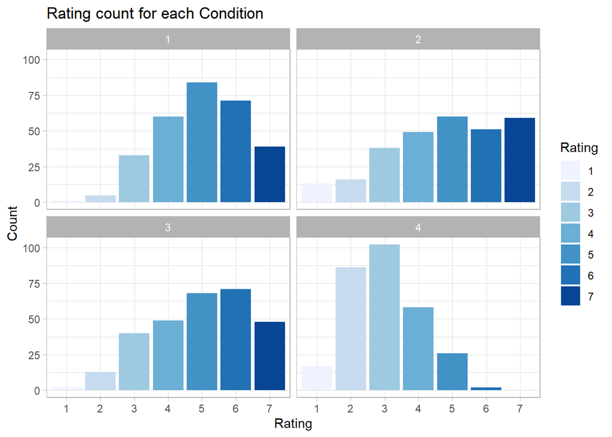

```r
behave_summary$Rating <- as.character(behave_summary$Rating)

ggplot(behave_summary) +
  aes(x = Rating, y = Count, fill = Rating) +
  geom_col() +
  scale_fill_brewer() +
  labs(title = "Rating count for each Condition") +
  theme_light() +
  facet_wrap(vars(Condition))
```

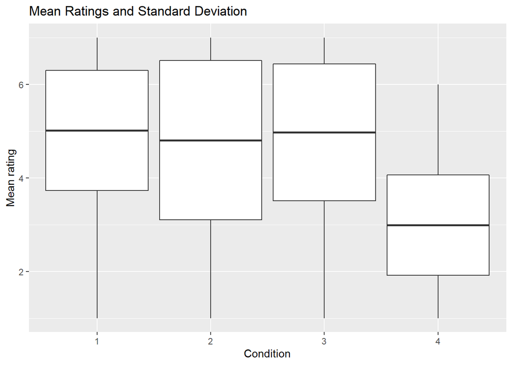

```r
ggplot(behave_statistics,aes(x=Condition))+
  geom_boxplot(aes(lower=Mean_rating- Standard_variation, upper= Mean_rating + Standard_variation, middle= Mean_rating, ymin= Minimum,ymax= Maximum),stat="identity")+
  labs(x = "Condition", y= "Mean rating", title = "Mean Ratings and Standard Deviation")
```

## R Session

R version 4.1.3 (2022-03-10) Platform: x86_64-w64-mingw32/x64 (64-bit) Running under: Windows 10 x64 (build 19044)

Matrix products: default

locale: [1] LC_COLLATE=Italian_Italy.1252 [2] LC_CTYPE=Italian_Italy.1252  
[3] LC_MONETARY=Italian_Italy.1252 [4] LC_NUMERIC=C  
[5] LC_TIME=Italian_Italy.1252

attached base packages: [1] stats graphics grDevices utils datasets [6] methods base

other attached packages: [1] data.table_1.14.2 esquisse_1.1.1  
[3] forcats_0.5.1 stringr_1.4.0  
[5] dplyr_1.0.8 purrr_0.3.4  
[7] readr_2.1.2 tidyr_1.2.0  
[9] tibble_3.1.6 tidyverse_1.3.1  
[11] rmarkdown_2.13 ggplot2_3.3.5  
[13] psych_2.2.3

loaded via a namespace (and not attached): [1] httr_1.4.2 sass_0.4.1  
[3] jsonlite_1.8.0 tmvnsim_1.0-2  
[5] modelr_0.1.8 bslib_0.3.1  
[7] shiny_1.7.1 assertthat_0.2.1  
[9] cellranger_1.1.0 yaml_2.3.5  
[11] pillar_1.7.0 backports_1.4.1  
[13] lattice_0.20-45 glue_1.6.2  
[15] digest_0.6.29 promises_1.2.0.1  
[17] rvest_1.0.2 colorspace_2.0-3  
[19] htmltools_0.5.2 httpuv_1.6.5  
[21] pkgconfig_2.0.3 broom_0.8.0  
[23] haven_2.5.0 xtable_1.8-4  
[25] scales_1.2.0 phosphoricons_0.1.2 [27] openxlsx_4.2.5 later_1.3.0  
[29] rio_0.5.29 tzdb_0.3.0  
[31] farver_2.1.0 generics_0.1.2  
[33] ellipsis_0.3.2 withr_2.5.0  
[35] datamods_1.3.2 cli_3.2.0  
[37] mnormt_2.0.2 magrittr_2.0.3  
[39] crayon_1.5.1 readxl_1.4.0  
[41] mime_0.12 evaluate_0.15  
[43] fs_1.5.2 fansi_1.0.3  
[45] nlme_3.1-155 xml2_1.3.3  
[47] foreign_0.8-82 tools_4.1.3  
[49] hms_1.1.1 lifecycle_1.0.1  
[51] munsell_0.5.0 reprex_2.0.1  
[53] zip_2.2.0 compiler_4.1.3  
[55] jquerylib_0.1.4 rlang_1.0.2  
[57] grid_4.1.3 rstudioapi_0.13  
[59] labeling_0.4.2 shinyWidgets_0.7.0 [61] gtable_0.3.0 DBI_1.1.2  
[63] curl_4.3.2 R6_2.5.1  
[65] lubridate_1.8.0 knitr_1.38  
[67] fastmap_1.1.0 utf8_1.2.2  
[69] stringi_1.7.6 parallel_4.1.3  
[71] Rcpp_1.0.8.3 vctrs_0.4.1  
[73] dbplyr_2.1.1 tidyselect_1.1.2  
[75] xfun_0.30